# COHA Dispersal Analysis: Complete Report

Natal Dispersal and Mass Distribution - 20 Ridgeline Variants

Author

COHA Research Team

Published

February 11, 2026

# 1 Executive Summary

This report presents a comprehensive analysis of Cooper’s Hawk (COHA) natal dispersal patterns and mass distributions using 20 ridgeline plot variants. The analysis employs a robust, quality-scored pipeline with comprehensive error handling and data validation.

## 1.1 Key Findings

- **Data Quality Score:** 100/100
- **Plot Generation Success:** 20/20 plots (100%)
- **Overall Pipeline Quality:** 100/100
- **Analysis Status:** SUCCESS

**NoteQuality Interpretation**

- **90-100:** Excellent - High confidence for publication
- **75-89:** Good - Acceptable with minor review
- **50-74:** Acceptable - Review recommended
- **0-49:** Poor - Investigation required

This analysis scored **100**, indicating excellent quality.

# 2 Data Overview

Dataset Summary Statistics

| Metric | Value |
| --- | --- |
| Total Observations | 411 |
| Years Covered | 1980 - 2025 |
| Mean Mass (g) | 331.5 |
| SD Mass (g) | 19.4 |
| Mass Range (g) | 275 - 397 |

## 2.1 Data Quality Metrics

Data Quality Assessment (4-Component System)

| Component | Value | Weight |
| --- | --- | --- |
| Completeness | 100.0% | 30% |
| Schema Match | 100.0% | 30% |
| Row Count | ✓ Pass (411 rows) | 20% |
| Outliers Detected | 0 | 20% |

**TipQuality Scoring System**

The data quality score is computed as a weighted average:

$$Q_{data} = 0.30 \times C_{complete} + 0.30 \times C_{schema} + 0.20 \times C_{rows} + 0.20 \times C_{outliers}$$

Where each component is scaled to [0, 100]. Final score: **100/100**

# 3 Ridgeline Plot Variants

## 3.1 Compact Variants (Scale: 0.85)

```
No compact plots found in registry.
```

## 3.2 Expanded Variants (Scale: 2.25)

```
No expanded plots found. Run the pipeline to generate plots.
```

# 4 Plot Generation Performance

Plot Generation Performance Metrics

[output not shown]

## 4.1 Individual Plot Quality

Individual Plot Generation Results

| Plot ID | Status | Quality (0-100) | Generation Time |
| --- | --- | --- | --- |
| compact_01 | success | 100 | 0.08s |
| compact_02 | success | 100 | 0.04s |
| compact_03 | success | 100 | 0.05s |
| compact_04 | success | 100 | 0.05s |
| compact_05 | success | 100 | 0.05s |
| compact_06 | success | 100 | 0.05s |
| compact_07 | success | 100 | 0.05s |
| compact_08 | success | 100 | 0.05s |
| compact_09 | success | 100 | 0.05s |
| compact_10 | success | 100 | 0.05s |
| expanded_01 | success | 100 | 0.05s |
| expanded_02 | success | 100 | 0.05s |
| expanded_03 | success | 100 | 0.05s |
| expanded_04 | success | 100 | 0.05s |
| expanded_05 | success | 100 | 0.05s |
| expanded_06 | success | 100 | 0.04s |
| expanded_07 | success | 100 | 0.05s |
| expanded_08 | success | 100 | 0.04s |
| expanded_09 | success | 100 | 0.04s |
| expanded_10 | success | 100 | 0.04s |

# 5 Biological Interpretation

## 5.1 Mass Distribution Patterns

Mass Distribution by Dispersal Status

| dispersed | N | Mean Mass (g) | SD Mass (g) | Min Mass (g) | Max Mass (g) |
| --- | --- | --- | --- | --- | --- |
| Unknown | 375 | 330.4 | 18.8 | 275 | 389 |
| Wisconsin | 36 | 342.3 | 22.1 | 305 | 397 |

## 5.2 Temporal Trends

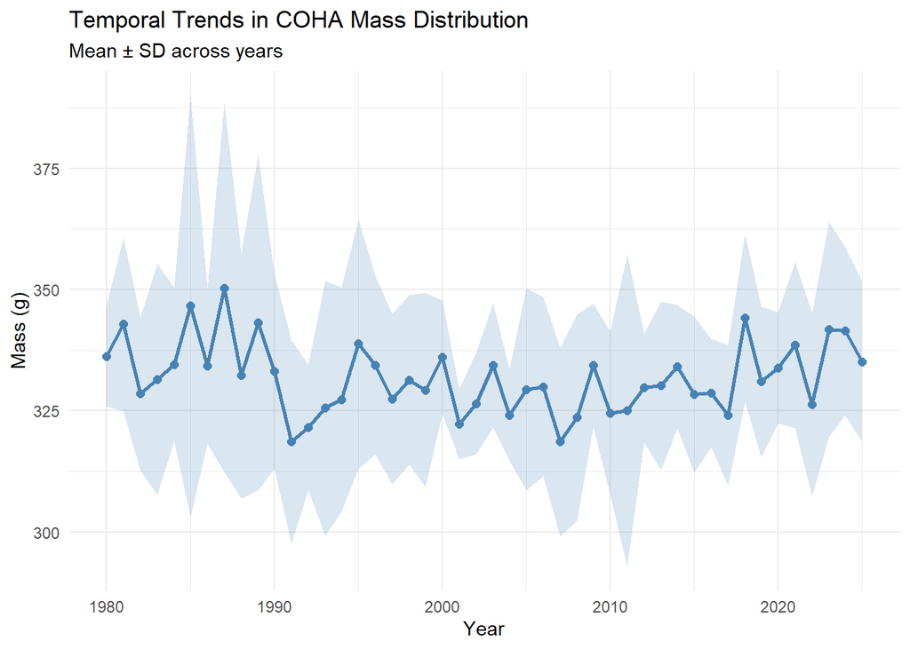

# 6 Methods

## 6.2 Quality Scoring Formula

### 6.2.1 Data Quality

$$Q_{data} = \sum_{i=1}^{4} w_i \times c_i$$

Where: - $c_1 = \text{Completeness}$ (% non-NA values) - $c_2 = \text{Schema Match}$ (% correct columns/types) - $c_3 = \text{Row Count}$ (meets minimum threshold) - $c_4 = \text{Outliers}$ (within expected ranges) - Weights: $w = [0.30, 0.30, 0.20, 0.20]$

### 6.2.2 Overall Pipeline Quality

$$Q_{overall} = 0.40 \times Q_{data} + 0.60 \times Q_{plots}$$

## 7.2 Pipeline Execution

```r
# Complete pipeline can be reproduced with:
source(here::here("R", "pipeline", "pipeline.R"))
result <- run_pipeline(verbose = TRUE)

# Results saved to: result$output_dir
# Log file: result$log_file
```

## 7.3 Data Access

- **Source Data:** `data/data.csv`
- **Configuration:** `inst/config/study_parameters.yaml`
- **Output Directory:** C:/Users/Triad/OneDrive/Documents/R Projects/COHA_Dispersal/results/plots/ridgeline/variants
- **Log File:** C:/Users/Triad/OneDrive/Documents/R Projects/COHA_Dispersal/logs/pipeline_2026-02-11.log
- **Analysis Date:** 2026-02-11 12:40:12

# 8 Appendix

## 8.1 Pipeline Result Object

```r
# Complete result structure
str(result, max.level = 2)
```

```
List of 16
 $ status            : chr "success"
 $ message           : chr "Pipeline complete: 20 plots generated"
 $ timestamp         : POSIXct[1:1], format: "2026-02-11 12:40:12"
 $ duration_secs     : num 17.6
 $ operation         : chr "run_pipeline"
 $ errors            : list()
 $ warnings          : list()
 $ quality_score     : num 100
 $ phase_results     :List of 2
  ..$ data_load      :List of 12
  ..$ plot_generation:List of 15
 $ data_quality_score: num 100
 $ plots_generated   : num 20
 $ plots_failed      : num 0
 $ output_dir        : chr "C:/Users/Triad/OneDrive/Documents/R Projects/COHA_Dispersal/results/plots/ridgeline/variants"
 $ log_file          : chr "C:/Users/Triad/OneDrive/Documents/R Projects/COHA_Dispersal/logs/pipeline_2026-02-11.log"
 $ pipeline_name     : chr "COHA Dispersal Ridgeline Analysis (Phase 3)"
 $ registry          :List of 5
  ..$ registry_version : chr "1.0"
  ..$ created_utc      : chr "2026-02-11T17:13:05Z"
  ..$ pipeline_version : chr "1.0"
  ..$ artifacts        :List of 24
  ..$ last_modified_utc: chr "2026-02-11T18:40:12Z"
  ..- attr(*, "path")= chr "C:/Users/Triad/OneDrive/Documents/R Projects/COHA_Dispersal/R/config/artifact_registry.yaml"
```

## 8.2 Configuration

```r
# Load study configuration
config <- load_study_config(verbose = FALSE)
str(config, max.level = 2)
```

```
List of 11
 $ project    :List of 5
  ..$ name       : chr "COHA Dispersal Analysis"
  ..$ version    : chr "1.0"
  ..$ description: chr "Publication-ready analyses of Cooper's Hawk natal dispersal patterns"
  ..$ authors    : chr "Analysis Team"
  ..$ created    : chr "2026-02-10"
 $ data       :List of 3
  ..$ source_file     : chr "data/data.csv"
  ..$ required_columns: chr [1:4] "mass" "year" "dispersed" "origin"
  ..$ column_types    :List of 4
 $ paths      :List of 4
  ..$ plots_base  : chr "results/plots"
  ..$ reports_base: chr "results/reports"
  ..$ logs_dir    : chr "logs"
  ..$ config_dir  : chr "inst/config"
 $ plot_types :List of 2
  ..$ ridgeline:List of 8
  ..$ boxplot  :List of 8
 $ defaults   :List of 8
  ..$ verbose         : logi FALSE
  ..$ save_plots      : logi TRUE
  ..$ generate_reports: logi TRUE
  ..$ dpi             : int 300
  ..$ format          : chr "png"
  ..$ alpha_fill      : num 0.7
  ..$ point_size      : int 2
  ..$ line_width      : num 0.8
 $ palettes   :List of 10
  ..$ viridis:List of 2
  ..$ plasma :List of 2
  ..$ inferno:List of 2
  ..$ magma  :List of 2
  ..$ cividis:List of 2
  ..$ rocket :List of 2
  ..$ mako   :List of 2
  ..$ turbo  :List of 2
  ..$ set2   :List of 2
  ..$ dark2  :List of 2
 $ logging    :List of 4
```

[output cut: 8 more lines]

```
  ..$ states           : chr [1:2] "Unknown" "Wisconsin"
 $ report     :List of 5
  ..$ generate_comprehensive: logi TRUE
  ..$ include_appendix      : logi TRUE
  ..$ format                : chr "html"
  ..$ theme                 : chr "default"
  ..$ gallery_variants      : int 20
 $ qa         :List of 3
  ..$ verify_outputs   : logi TRUE
  ..$ check_determinism: logi FALSE
  ..$ create_qa_log    : logi TRUE
 $ publication:List of 3
  ..$ journal_target   : chr "Ornithological Research"
  ..$ data_availability:List of 2
  ..$ reproducibility  :List of 2
```